# probabilidad

Andrés Aldana

6/19/2021

# 1 Índice

- Distribuciones de probabilidad
  - Discretas
    - Bernoulli
    - Binomial
    - Geométrica
    - Binomial Negativa
    - Poisson
    - Hipergeométrica
  - Continuas
    - Uniforme
    - Exponencial
    - Normal

# 2 Conjuntos

```r
Omega = c(1,2,3,4,5,6,7,8,9,10)
A=c(1,2,3,4,5)
B=c(1,4,5)
C=c(4,6,7,8)
Omega
```

```
##  [1]  1  2  3  4  5  6  7  8  9 10
```

```r
union(A,B)
```

```
## [1] 1 2 3 4 5
```

```r
intersect(A,B)
```

```
## [1] 1 4 5
```

```r
setdiff(A,B)
```

```
## [1] 2 3
```

```python
Omega=set([1,2,3,4,5,6,7,8,9,10])
A=set([1,2,3,4,5])
B=set([1,4,5])
C=set([4,6,7,8])
Omega
## {1, 2, 3, 4, 5, 6, 7, 8, 9, 10}
A & B # intersección
## {1, 4, 5}
A | B # unión
## {1, 2, 3, 4, 5}
A - B
## {2, 3}
```

## 2.1 Combinaciones (orden no importa, sin repetición)

Número de subconjuntos de tamaño $k$ de un conjunto de tamaño $n$. Este número es

$$C_n^k={{n}\choose{k}} = \frac{n!}{k!\cdot (n-k)!}$$

donde

$$n! = 1\cdot2\cdot3\cdots n$$

Entonces si $n=7$ y $k=5$

$${7\choose5}=\frac{7!}{5!\cdot(7-5)!}=\frac{7!}{5!\cdot2!}=\frac{1\cdot2\cdot3\cdot4\cdot5\cdot6\cdot7}{1\cdot2\cdot3\cdot4\cdot5\cdot1\cdot2}=\frac{6\cdot7}{2}=\frac{42}{2}=21$$

De un conjunto de 7 elementos, se pueden formar 21 subconjuntos diferentes de 5 elementos.

```r
n = 7
k = 5
factorial(n)/(factorial(k)*factorial(n-k))
```

```
## [1] 21
```

```r
library(gtools)
#?combinations -> Enumerate the Combinations of the Elements of a Vector
# combinations(n, r, v=1:n, set=TRUE, repeats.allowed=FALSE)
# n = Size of the source vector
# r = Size of the target vectors
# v = Source vector
# Logical flag indicating whether duplicates should be removed from the source vector v.
#Logical flag indicating whether the constructed vectors may include duplicated values.
combinations(n, k)
```

```
##       [,1] [,2] [,3] [,4] [,5]
##  [1,]    1    2    3    4    5
##  [2,]    1    2    3    4    6
##  [3,]    1    2    3    4    7
##  [4,]    1    2    3    5    6
##  [5,]    1    2    3    5    7
##  [6,]    1    2    3    6    7
##  [7,]    1    2    4    5    6
##  [8,]    1    2    4    5    7
##  [9,]    1    2    4    6    7
## [10,]    1    2    5    6    7
## [11,]    1    3    4    5    6
## [12,]    1    3    4    5    7
## [13,]    1    3    4    6    7
## [14,]    1    3    5    6    7
## [15,]    1    4    5    6    7
## [16,]    2    3    4    5    6
## [17,]    2    3    4    5    7
## [18,]    2    3    4    6    7
## [19,]    2    3    5    6    7
## [20,]    2    4    5    6    7
## [21,]    3    4    5    6    7
```

## 2.2 Variaciones (orden importa, sin repetición)

Denotaremos las variaciones (sin repeticion) de $k$ elementos (de orden $k$) de un conjunto de $n$ elementos por $V_n^k$ su valor es

$$V_n^k=\frac{n!}{(n-k)!}=(n-k+1)\cdot(n-k+2)\cdots n$$

```r
n = 3
k = 2
factorial(n)/factorial(n-k)
```

```
## [1] 6
```

```r
library(gtools)
#?permutations -> Enumerate the Permutations of the Elements of a Vector
# permutations(n, r, v=1:n, set=TRUE, repeats.allowed=FALSE)
# n = Size of the source vector
# r = Size of the target vectors
# v = Source vector
# Logical flag indicating whether duplicates should be removed from the source vector v.
#Logical flag indicating whether the constructed vectors may include duplicated values.
permutations(3,2)
```

```
##      [,1] [,2]
## [1,]    1    2
## [2,]    1    3
## [3,]    2    1
## [4,]    2    3
## [5,]    3    1
## [6,]    3    2
```

## 2.3 Variaciones con repetición (orden importa)

$$VR_n^k=n^k$$

## 2.4 Permutaciones (orden importa, sin repetición)

Las permutaciones de un conjunto cardinal $n$ don todas las variaciones de orden máximo $n$. Se denotan y vale:

$$P_n=VR_n^n=n!$$

```r
library(combinat)
for (perm in permn(3)) print(perm)
```

```
## [1] 1 2 3
## [1] 1 3 2
## [1] 3 1 2
## [1] 3 2 1
## [1] 2 3 1
## [1] 2 1 3
```

```python
from itertools import combinations, combinations_with_replacement, permutations
from scipy.special import comb
```

## 2.5 Combinaciones con repetición (orden no importa)

$$CR_n^k={{n+k-1}\choose{k}}=\frac{(n+k-1)!}{k!(n-1)!}$$

```r
n = 12
k = 4

factorial(n+k-1)/(factorial(k)*factorial(n-1))
```

```
## [1] 1365
```

## 2.6 Permutaciones con repetición

Considerando el conjunto de elementos $\{a_1, a_2,\dots,a_k\}$

Entonces, si cada uno de los objetos $a_i$ de un conjunto, aparece repetido $n_i$ veces para cada $i$ desde $1$ hasta $k$, entonces el número de permutaciones con elementos repetidos es:

$$PR_{n}^{n_1,n_2,\dots,n_k}={{n}\choose{n_1\quad n_2\quad\dots\quad n_k}}=\frac{n!}{n_1!\cdot n_2!\cdot\ldots\cdot n_k!}$$

donde $n=n_1+n_2+\cdots+n_k$

Usos: ¿Cúantas palabras diferentes se pueden formar con las letras de la palabra ‘probabilidad’?

# 3 Probabilidad

### 3.0.1 Propiedades

- $P(\emptyset)=0$
- $P(A-B)=P(A)-P(A\cap B)$
- $B\subseteq A$, entonces $0\le P(B)\le P(A)$
- $P(A^C)=1-P(A)$
- $P(A\cup B)=P(A)+P(B)-P(A\cap B)$
- $P(A\cup B\cup C)=P(A)+P(B)+P(C)-P(A\cap B)-P(A\cap C)-P(B\cap C)+P(A\cap B\cap C)$

## 3.1 Probabilidad condiconal

$$P(B|A)=\frac{P(A\cap B)}{P(A)}$$

### 3.1.1 Propiedades

- $P(B^C|A)=1-P(B|A)$
- $P(B_1\cup B_1|A)=P(B_1|A)+P(B_2|A)-P(B_1\cap B_2|A)$

## 3.2 Teorema de la probabilidad total

$$P(B)=P(B\cap A)+P(B\cap A^C)$$

entonces

$$P(B)=P(A)\cdot P(B|A)+P(A^C)\cdot P(B|A^C)$$

## 3.3 Matriz de confusión

|  | El test da Positivo | El test da Negativo |
| --- | --- | --- |
| **Condición Positiva** | Correcto (Verdadero Positivo) | Error (Falso Negativo) |
| **Condición Negativa** | Error (Falso Positivo) | Correcto (Verdadero Negativo) |

## 3.4 Fórmula de Bayes

$$P(A|B)=\frac{P(A)\cdot P(B|A)}{P(B)}$$

### 3.4.1 Usando el teorema de la probabilidad total

$$P(A|B)=\frac{P(A)\cdot P(B|A)}{P(B|A)\cdot P(A)+P(B|A^C)\cdot P(A^C)}$$

## 3.5 Sucesos independientes

Los sucesos $A$ y $B$ son **independientes** si $P(A\cap B)=P(A)\cdot P(B)$

$A_1,\dots,A_n$, son sucesos **independientes** cuando, para toda subfamilia $A_{i_1},\dots,A_{i_k}$,

$$P(A_{i_1}\cap\cdots\cap A_{i_k})=P(A_{i_1})\cdots P(A_{i_k})$$

**Proposición:** Dados dos sucesos $A$ y $B$ con $P(A),P(B)>0$, las siguientes afirmaciones son equivalentes:

- $A$ y $B$ son independientes
- $P(A|B)=P(A)$
- $P(B|A)=P(B)$

## 3.6 Función de probabilidad discreta $f_{_X}(x)$

La función de probabilidad (probability mass function o probability density function) de una variable aleatoria v.a. X, que se denota por $P_X(x)$, está definida por

$$P_X(x)=P(X=x)$$

es decir, la probabilidad de que $X$ tome el valor $x$

### 3.6.1 Dominio de una variable aleatoria discreta

El conjunto

$$D_X=\{x \in \mathbb{R}\ |\ P_X(x)>0\}$$

recibe el nombre de *dominio* dela v.a. y son los valores posibles de esta variable.

## 3.7 Función de distribución de probabilidad $F_{_X}(x)$

La función de distribución de probabilidad (acumulada) de la v.a. $X$ (de cualquier tipo; discreta o continua) $F_X(x)$ representa la probabilidad de que $X$ tome un valor menor o igual que $x$, es decir

$$F_X(x)=P(X\le x)$$

Esta función también se denomina función de distribución de una v.a. o *cumulative density function* que se puede abreviar como **cdf**.

### 3.7.1 Propiedades

Sea $X$ una v.a. y $F_X$ su función de distribución:

- $P(X>x)=1-P(X\le x)=1-F_X(x)$
- Sea $a$ y $b$ tales que $a<b$, $P(a<X\le b)=P(X\le b)-P(X\le a)=F_X(b)-F_X(a)$
- $0\le F_X(x)\le 1$
- La función $F_X$ es no decreciente
- La función $F_X$ es continua por derecha
- Si $F_X$ es continua en $x$ se tiene que $P(X=x)=0$. Así que si la v.a. es continua $P(X\le a)=P(X<a)+P(X=a)=P(X<a)$ y propiedades similares.
- Sea $X$ una v.a. discreta con dominio $D_X$ y que tiene por función de probabilidad $P_X(x)$ entonces su función de distribución $F_X(x_0)$ es

$$F_X(x_0)=\sum_{x\le x_0}{P_X(x)}$$

donde $\sum_{x\le x_0}$ indica que sumamos todos los $x \in D_X$ tales que $x \le x_0$

## 3.8 Valor esperado $E(X)$

El *valor esperado* o *esperanza* (*expected value*) $E(X)$ de una v.a. discreta $X$, se define como

$$E(X)=\sum_{x \in X(\Omega)}{xP_X(x)}$$

En ocasiones de le denomina *media* (*mean*) poblacional o simplemente media y muy frecuentemente se le denota $\mu_X=E(X)$ o simplemente $\mu=E(X)$

Sea $X$ una v.a. discreta con función de probabilidad $P_X$ y de distribución $F_X$. Entonces el *valor esperado* de una función $g(x)$ es:

$$E(g(X))=\sum_{x}{g(x)P_X(x)}$$

```r
s = 0
v = 1/2
for (k in 7:107) {
  s = s + v^k;
}
s
```

```
## [1] 0.015625
```

```r
v^7/(1-v)
```

```
## [1] 0.015625
```

## 3.9 Series geométricas

Una progresión geométrica de razón $r$ es una sucesión de la forma

$$r^0, r^1, \dots, r^n, \dots, .$$

La serie geométrica es la suma de todos los valores de la progresión geométrica $\sum_{k=0}^{+\infty}{r^k}$

Las sumas parciales desde el término $n_0$ al $n$ de una progresión geométrica valen

$$\sum_{k=n_0}^{n}{r^k}=\frac{r^{n_0}-r^{n}r}{1-r}$$

### 3.9.1 Propiedades

- Si $|r|<1$ la serie geométrica es convergente y

$$\sum_{k=0}^{+\infty}{r^k}=\frac{1}{1-r}$$

- En el caso de que se comience en $n_0$ se tiene que

$$\sum_{k=n_0}^{+\infty}{r^k}=\frac{r^{n_0}}{1-r}$$

- Si $|r|<1$ también son convergentes las derivadas, respecto de $r$, de la serie geométrica y convergen a la derivada correspondiente. Así tenemos que

$$\left(\sum_{k=0}^{+\infty}{r^k}\right)'=\sum_{k=1}^{+\infty}{kr^{k-1}}\quad\text{entonces}\quad\left(\frac{1}{1-r}\right)'=\frac{1}{(1-r)^2}$$

$$\left(\sum_{k=0}^{+\infty}{r^k}\right)''=\sum_{k=2}^{+\infty}{k(k-1)r^{k-2}}\quad\text{entonces}\quad\left(\frac{1}{1-r}\right)''=\frac{2}{(1-r)^3}$$

## 3.10 Varianza de una v.a.

Sea $X$ una v.a. llamaremos varianza de $X$ a

$$Var(X)=E\left((X-E(X))^2\right)$$

Por lo tanto la varianza es el momento central de orden 2.

De forma frecuente se utiliza la notación

$$\sigma_X^2=Var(X)$$

A la raíz cuadrada positiva de la varianza

$$\sigma_X=\sqrt{Var(X)}$$

se le denomina desviación típica o estándar de $X$

## 3.11 Variable aleatoria continua $X$

### 3.11.1 Valor esperado (Esperanza) $E(X)$

$$E(X)=\int_{-\infty}^{+\infty}{x \cdot f_{_X}(x)dx}$$

Si $g(x)$ es una función de la variable $X$ entonces:

$$E(g(X))=\int_{-\infty}^{+\infty}{g(x) \cdot f_{_X}(x)dx}$$

### 3.11.2 Varianza $Var(X)$

$$Var(x) = \sigma_{X}^{2} = E((X - \mu_{X})^2) = \int_{-\infty}^{+\infty}{(x-\mu_X)^2 \cdot f_{_X}(x)dx}$$

$$Var(x) = \sigma_{X}^{2} = E(X^2) - \mu_{X}^2 = \int_{-\infty}^{+\infty}{x^2 \cdot f_{_X}(x)dx}-\mu_{X}^{2}$$

### 3.11.3 Desviación típica $\sigma_{_X}$

$$\sigma_{_X} = +\sqrt{\sigma_{_X}^2}$$

### 3.11.4 Transformaciones lineales

Sea $X$ una v.a. continua con $E(X)=\mu_{X}$ y $Var(X)=\sigma_X^2$. Sea $Y=a+bX$, donde $a,b\in\mathbb{R}$, es una nueva v.a. continua obtenida mediante una transformación lineal de $X$. Se verifican las mismas propiedades que en el caso discreto:

- $E(Y) = E(a+bX) = a+bE(X)$
- $Var(Y) = Var(a+bX) = b^2 Var(X)$
- $\sigma_Y = |b|\sigma_X$
- $Z = \frac{X - \mu_X}{\sigma_X}$ es una transformación lineal de $X$ de forma que

$$E(Z) = 0\ \ \text{y}\ \ Var(Z)=1$$

$$$$

# 4 Distribuciones de probabilidad

$p(X\le a)=F(a)$

Coeficiente de asimetría

$$$$

## 4.1 R

- `dva(x, ...)`: Función de densidad o de probabilidad $f(x)$ de la variable aleatoria para el valor $x$ del dominio de definición.
- `pva(x, ...)`: Función de distribución $F(x)$ de la variable aleatoria para el valor x del dominio de definición.
- `qva(x, ...)`: Cuantil *p*-ésimo de la variable aleatoria (el valor de $x$ más pequeño tal que $F(x)\ge p$.
- `rva(x, ...)`: Generador de n observaciones siguiendo la distribución de la variable aleatoria.

## 4.2 Python

- `pmf`: Probability Mass Function
- `pdf`: Probability Density Function
- `cdf`: Cumulative Distribution Function
- `ppf`: Percent Point Function (Inverse of CDF)
- `rvs`: Random Variates

## 4.3 Discretas

### 4.3.1 Bernoulli

Si $X$ es v.a. que mide el **número de éxitos** y se realiza un único experimento con dos posibles resultados (éxito, que toma un valor de 1, o fracaso, que toma valor 0), se dice que $X$ se distribuye como una **Bernoulli** con parámetro $p$

$$X \sim \text{Be}(p)$$

donde $\ p\$ es la probabilidad de éxito y $\ q = 1 - p\$ es la probabilidad de fracaso.

- El **dominio** de $X$ es $X(\Omega)=\{0,1\}$
- La **función de probabilidad** está dada por

$$f_X(x)=p^x(1-p)^{1-x}, \quad x \in \{0,\ 1\}=
\left\{
\begin{array}{rl}
p \quad& \text{si }\ x = 1 \\
1 - p \quad & \text{si }\ x = 0 \\
0 \quad & \text{en cualquier otro caso}
\end{array}
\right.$$

donde $\ x \in \{0,\ 1\}$

- La **función de distribución** está dada por

$$F_X(x)=
\left\{
\begin{array}{rl}
0 \quad & \text{si }\ x < 0 \\
1-p \quad & \text{si }\ 0 \le x < 1 \\
1 \quad & \text{si }\ x \ge 1
\end{array}
\right.$$

- La **Esperanza** es $E(X)=p$
- La **Varianza** es $Var(X)=pq$
- El **Momento de orden $n$** es $E(X^n)=p$

#### 4.3.1.1 Funciones en `R`

```r
library(Rlab)
# prob = probabilidad de éxito
dbern(x, prob)
pbern(q, prob)
qbern(p, prob)
rbern(n, prob)
```

#### 4.3.1.2 Funciones en `python`

```python
from scipy.stats import bernoulli
# p = probabilidad de éxito
bernoulli.pmf(k, p)
bernoulli.cdf(k, p)
bernoulli.ppf(q, p)
bernoulli.rvs(p, size)
```

#### 4.3.1.3 Ejercicio

Sea $\ X = Be(p=0.7)$, la distribución que modela la probabilidad de obtener una cara usando una moneda trucada. La probabilidad de obtener cara es 70%.

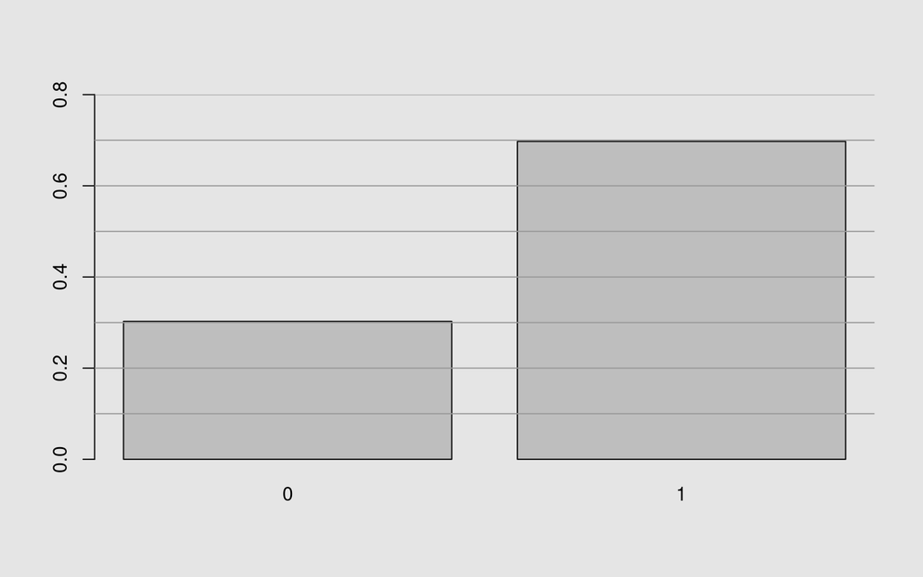

```r
#packages.install("Rlab")
library(Rlab)
# Probabilidad de éxito (1)
p = 0.7
# Probabilidad de obtener 0
dbern(0, prob=p)
[1] 0.3
# Probabilidad de obtener 1
dbern(1, prob=p)
[1] 0.7
# Probabilidad acumulada de obtener 0
pbern(0, prob=p)
[1] 0.3
# Probabilidad acumulada de obtener 1
pbern(1, prob=p)
[1] 1
# Mediana
qbern(0.5, prob=p)
[1] 1
# Primer cuartil
qbern(0.25, prob=p)
[1] 0
# Barplot
par(bg='gray90')
barplot(
  prop.table(table(rbern(10000, prob=p))),
  ylim=c(0,0.8))
abline(h=seq(0.1, 0.8, by=0.1), col='gray60')
```

###### 4.3.1.3.0.1 (volver al índice)

### 4.3.2 Binomial

Si $X$ es una v.a. que mide el **número de éxitos** y se realizan $n$ ensayos de **Bernoulli** independientes entre sí, se dice que $X$ se distribuye como una **Binomial** con parámetros $n$ y $p$

$$X\sim \text{B}(n, p)$$

donde $p$ es la probabilidad de éxito y $q=1-p$ es la probabilidad de fracaso

- El **dominio** de $X$ será $D_X=\{0, 1, 2, \dots, n\}$
- La **función de densidad** está dada por:

$$f_X(x)={n\choose x}p^x(1-p)^{n-x}$$

- La **función de distribución** está dada por:

$$F_X(x)=
\left\{
\begin{array}{rl}
0 \quad & \text{si } x < 0 \\
\sum_{k=0}^{x}{}f(k) \quad & \text{si } 0 \le x < n \\
1 \quad & \text{si } x \ge n
\end{array}
\right.$$

- La **Esperanza** es $E(X)=np$
- La **Varianza** es $Var(X)=npq$

#### 4.3.2.1 Funciones en `R`

```r
# library(Rlab) # aunque ya está en el paquete stats
# prob = probabilidad de éxito
# size = número de ensayos del experimento
dbinom(x, size, prob)
pbinom(q, size, prob)
qbinom(p, size, prob)
rbinom(n, size, prob)
```

#### 4.3.2.2 Funciones en `python`

```python
from scipy.stats import binom
# p = probabilidad de éxito
# n = número de ensayos del experimento
binom.pmf(k, n, p)
binom.cdf(k, n, p)
binom.ppf(q, n, p)
binom.rvs(n, p, size)
```

#### 4.3.2.3 Ejercicio

Sea $X = \text{B}(n=30, p=0.6)$

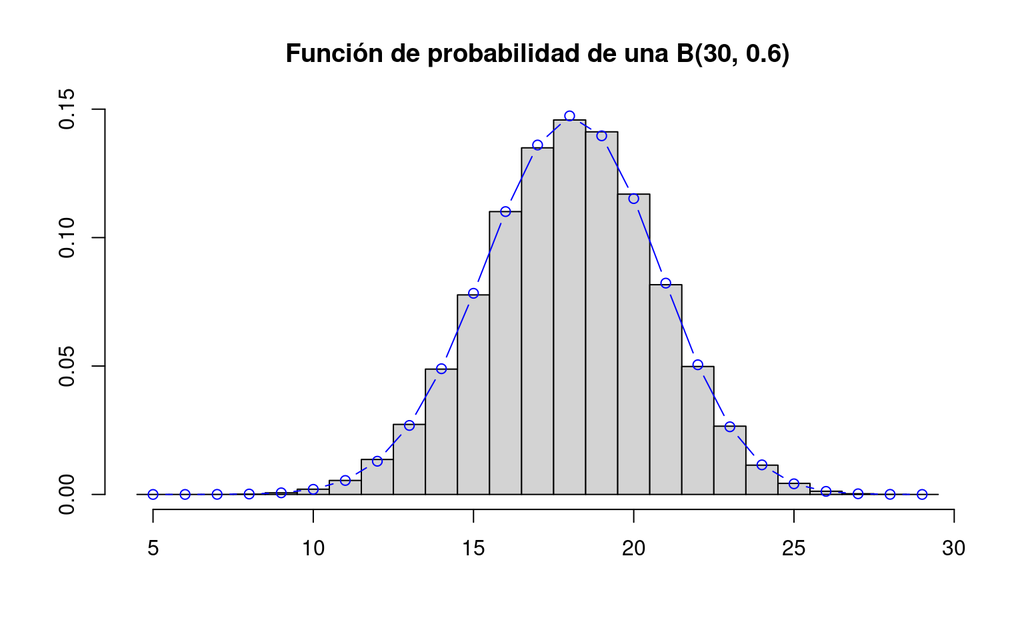

```r
library(reticulate)
#library(Rlab)
n = 30
p = 0.6
# Primer cuartil
qbinom(0.25, n, p)
[1] 16
# Mediana
qbinom(0.5, n, p)
[1] 18
# Tercer cuartil
qbinom(0.75, n, p)
[1] 20
# Generación de valores aleatorios
v = rbinom(100000, n, p)
x = min(v):max(v)
# Histogram
breaks = seq(min(x)-0.5, max(x)+0.5, by=1)
hist(v, breaks=breaks,
  main="Función de probabilidad de una B(30, 0.6)",
  xlab="",
  ylab="",
  freq=FALSE)
lines(x, dbinom(x, n, p), type='b', col='blue')
```

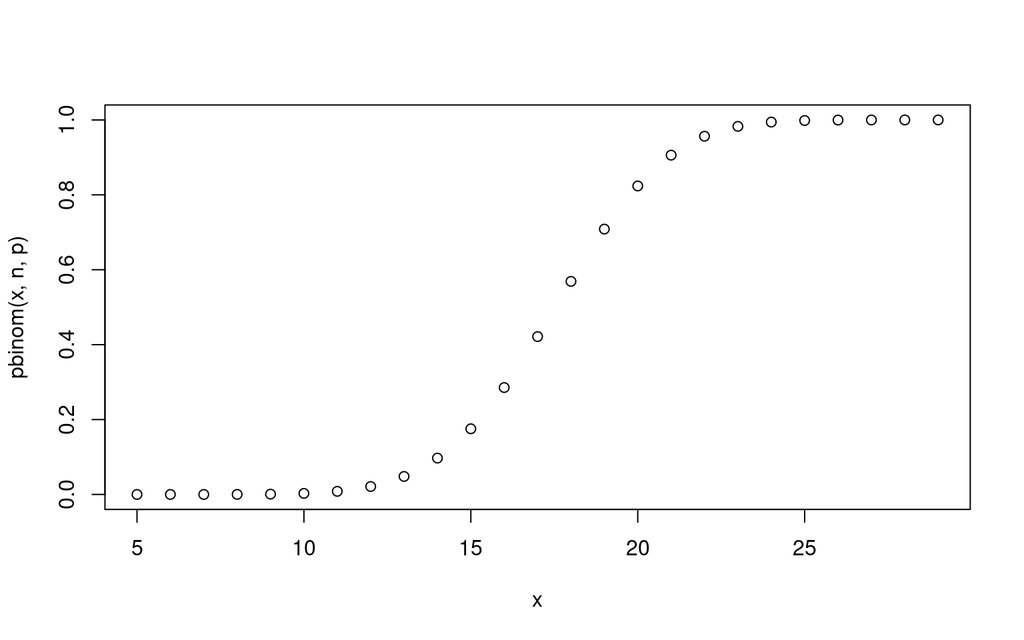

```r
plot(x, pbinom(x, n, p))
```

###### 4.3.2.3.0.1 (volver al índice)

### 4.3.3 Geométrica

Si $X$ es v.a. que mide el **número de repeticiones independientes del experimento hasta haber conseguido el primer éxito**, se dice que $X$ se distribuye como una **Geométrica** con parámetro $\ p$

$$X \sim \text{Ge}(p)$$

donde $\ p\$ es la probabilidad de éxtio, y $\ q=1-p\$ es la probabilidad de fracaso

- El **Dominio** de $X$ será $D_X=\{0,1,2,\dots\}$ o bien $D_X=\{1,2,\dots\}$ en función de si empieza en 0 o en 1 respectivamente. Empieza en 0 cuando se mide el número de fracasos, y empieza en 1 cuando se mide el número de intentos hasta conseguir el primer éxito
- La **función de densidad** está dada por:

$$f_X(x)=
\left\{
\begin{array}{ll}
(1-p)^{x}p \qquad & \text{si empieza en 0} \\
(1-p)^{x-1}p \qquad & \text{si empieza en 1}
\end{array}
\right.$$

- La **función de distribución** está dada por (empezando en 0)

$$F_X(x) =
P(X \le x) =
\left\{
\begin{array}{rl}
0 \quad & \text{si }\ x<0 \\
1-(1-p)^{k+1} \quad & \text{si }\ \left\{\begin{array}{l}k \le x < k+1 \\ \text{para }\ k = 0,1,2,\dots\end{array}\right.
\end{array}
\right.$$

- La **esperanza** es $\ E(X)=\frac{1-p}{p}\$ si empieza en 0 y $\ E(X)=\frac{1}{p}\$ si empieza en 1
- La **varianza** $\ Var(X)=\frac{1-p}{p^2}$
- **Propiedad de la falta de memoria**: Si $\ X\$ es una v.a. $\ \text{Ge}(p)\$, entonces

$$p(X > m+n|X\ge n)=p(X > m)\ \ \forall\ \ m, n = 0,1,\dots$$

#### 4.3.3.1 Funciones en `R`

```r
# prob = probabilidad de éxito del experimento
dgeom(x, prob)
pgeom(q, prob)
qgeom(p, prob)
rgeom(n, prob)
```

#### 4.3.3.2 Funciones en `python`

```python
from scipy.stats import geom
# p = probabilidad de éxito del experimento
# Con python la geométrica empieza en uno, cuenta el número de intentos hasta conseguir el primer éxito, si se quiere contar fracasos hasta el primer éxito, se debe aregar el parámetro loc=-1
geom.pmf(k, p)
geom.cdf(k, p)
geom.ppf(q, p)
geom.rvs(p, size)
```

#### 4.3.3.3 Ejercicio

Sea $X=\text{Ge}(p=0.25)$ la distribución que modela la probabilidad de intentar abrir una puerta hasta conseguirlo.

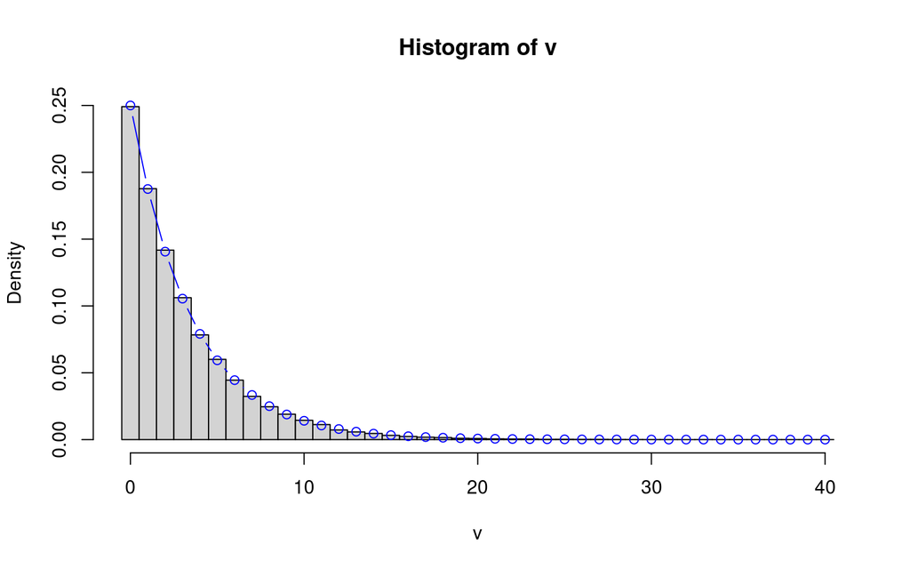

```r
# Probabilidad de éxito
p = 0.25
# Probabilidad de acertar en el primer intento
dgeom(0, p)
[1] 0.25
# Probabilidad de acertar en el segundo intento
dgeom(1, p)
[1] 0.1875
# Probabilidad acumulada de haber acertado en el sexto intento
pgeom(5, p)
[1] 0.8220215
# Mediana
qgeom(0.5, p)
[1] 2
# Primer cuartil
qgeom(0.25, p)
[1] 0
# Generación de valores aleatorios
rgeom(100000, p) -> v
x = min(v):max(v)
# Histogram
hist(v, freq=FALSE, breaks=seq(min(x)-0.5, max(x)+0.5, by=1))
lines(x, dgeom(x, p), type='b', col='blue')
```

###### 4.3.3.3.0.1 (volver al índice)

### 4.3.4 Binomial Negativa

Si $X$ es una variable aleatoria que mide el **número de repeticiones hasta observar los $r$ éxitos en ensayos de Bernoulli**, se dice que $X$ se distribuye como una Binomial Negativa con parámetros $r$ y $p$

$$X \sim \text{BN}(r,p)$$

donde $p$ es la probabilidad de éxito

- El **dominio** de $X$ será $D_X=\{r,\ r+1,\ r+2,\ \dots\}$
- La **función de densidad** está dada por

$$f(k)={k-1 \choose r-1}p^r(1-p)^{k-r},\qquad k \ge r$$

- La **función de distribución** no tiene una expresión analítica
- La **Esperanza** es $E(X)=\frac{r}{p}$
- La **varianza** es $Var(X)=r \frac{1-p}{p^2}$

#### 4.3.4.1 Funciones en `R`

```r
# size = número de casos exitosos
# prob = probabilidad de éxito
dnbinom(x, size, prob)
pnbinom(q, size, prob)
qnbinom(p, size, prob)
rnbinom(n, size, prob)
```

#### 4.3.4.2 Funciones en `python`

```python
from scipy.stats import nbinom
# n = número de casos exitosos
# p = probabilidad de éxito
nbinom.pmf(k, n, p)
nbinom.cdf(k, n, p)
nbinom.ppf(q, n, p)
nbinom.rvs(n, p)
```

#### 4.3.4.3 Ejercicio

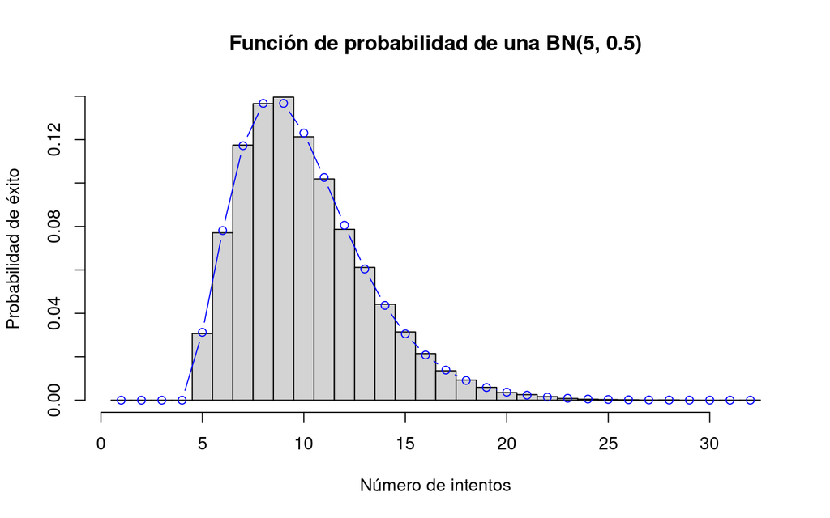

```r
# número de éxitos que se buscan
n = 5
# probabilidad de éxito
p = 0.5
# probabilidad de obtener r aciertos en el intento número 7
dnbinom(7-n, n, p)
[1] 0.1171875
# Generación de valores aleatorios
rnbinom(100000, n, p) -> v
x = min(v):max(v)
# Histograma
hist(v+n, breaks=seq(0.5, max(v)+n+0.5, by=1),
  main="Función de probabilidad de una BN(5, 0.5)",
  xlab="Número de intentos",
  ylab="Probabilidad de éxito",
  freq=FALSE)
lines(c(1:(n-1), x+n), c(rep(0, n-1), dnbinom(x, n, p)), type='b', col='blue')
```

```python
# En este caso se busca es número de fallos antes de obtener n aciertos, no el total de intentos hasta obtener n aciertos
from scipy.stats import nbinom
n, p = 5, 0.5
params = nbinom.stats(n, p, moments='mv')
print('E(X) = {m}'.format(m = params[0]))
## E(X) = 5.0
print('Var(X) = {v}'.format(v = params[1]))
## Var(X) = 10.0
```

###### 4.3.4.3.0.1 (volver al índice)

### 4.3.5 Poisson

Si $X$ es una v.a. que mide el **número de eventos en un cierto intervalo de tiempo**, se dice que $X$ se distribuye como una **Poisson** con parámetro $\lambda$

$$X\sim \text{Po}(\lambda)$$

donde $\lambda$ representa le número de veces que se espera que ocurra el evento durante un intervalo de tiempo dado

- El **dominio** de $X$ será $D_X=\{0,1,2,\dots\}$
- La **función de densidad** está dada por

$$f_X(x) =
P(X=x) =
\left\{
\begin{array}{ll}
\displaystyle\frac{\lambda^x}{x!}e^{-\lambda} & \text{si }\ x = 0,1,2,\dots \\[5pt]
0 & \text{en otro caso}
\end{array}
\right.$$

- La **función de distribución** está dada por

$$F_X(x) =
P(X \le x) =
\left\{
\begin{array}{rl}
0 \quad & \text{si }\ x<0 \\
\displaystyle\sum_{i=0}^{k}{f_X(i)} \quad & \text{si }\ k \le x < n \\
1 \quad & \text{si }\ x \ge n
\end{array}
\right.$$

- La **Esperanza** es $E(X)=\lambda$
- La **Varianza** es $Var(X)=\lambda$

#### 4.3.5.1 Funciones en `R`

```r
# lambda = número esperado de eventos por unidad de tiempo de la distribución
dpois(x, lambda)
ppois(q, lambda)
qpois(p, lambda)
rpois(n, lambda)
```

#### 4.3.5.2 Funciones en `python`

```python
from scypy.stats import poisson
# mu = número esperado de eventos por unidad de tiempo de la distribución
poisson.pmf(k, mu)
poisson.cdf(k, mu)
poisson.ppf(q, mu)
poisson.rvs(M, mu)
```

#### 4.3.5.3 Ejercicio

Supongamos que $X$ modela el número de errores por página que tiene un valor esperado $\lambda = 5$.

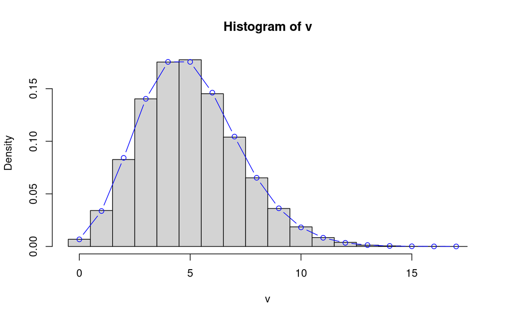

```r
# lambda
l = 5
# Probabilidad de cometer 3 errores
dpois(3, l)
[1] 0.1403739
# Probabilidad de cometer 3 errores o menos
ppois(3, l)
[1] 0.2650259
sum(dpois(0:3, l))
[1] 0.2650259
# Primer cuartil
qpois(0.25, l)
[1] 3
# Mediana
qpois(0.5, l)
[1] 5
# Tercer cuartil
qpois(0.75, l)
[1] 6
# Generación de valores aleatorios
rpois(n=100000, lambda=l) -> v
x = min(v):max(v)
# Histograma
hist(v, breaks=seq(min(x)-0.5, max(x)+0.5, by=1), freq=FALSE)
lines(x, dpois(x, lambda=l), type='b', col='blue')
```

###### 4.3.5.3.0.1 (volver al índice)

### 4.3.6 Hipergeométrica

Considerando el experimento **“extraer a la vez (o una detás de otra, sin retornarlos) $k$ objetos donde hay $m$ de tipo A y $n$ de tipo B”**. Si $X$ es v.a. que mide el **número de objetos del tipo A**, se dice que $X$ se distribuye como una **Hipergeométrica** con parámetros $m$, $n$, $k$

$$X \sim \text{H}(m, n, k)$$

- El **dominio** de $X$ será $D_X=\{x \in \mathbb{N} | \max\{0, k - n\} \le x \le \min\{m, k\}\}$ (en general)
- La **función de densidad** está dada por

$$f_X(x) =
P_X(x) =
\left\{
\begin{array}{ll}
\displaystyle \frac{{{m} \choose {x}} \cdot {{n} \choose {k-x}}}{{m+n} \choose {k}} & \text{si }\ \max\{0, k-n\} \le x \le \min\{m,k\}\ \text{ para }\ x \in \mathbb{N} \\
0 & \text{en otro caso}
\end{array}
\right.$$

- La **función de distribución** está dada por

$$F(x)=
\left\{
\begin{array}{rl}
0 \quad & \text{si }\ x < 0 \\
\displaystyle \sum_{k=0}^{x}{f(k)} \quad & \text{si }\ 0 \le x < n \\
1 \quad & \text{si }\ x \ge n
\end{array}
\right.$$

- La **esperanza** es $\displaystyle{E(X)=\frac{k \cdot m}{m + n}}$
- La **varianza** es

$$Var(X)=k \cdot \frac{m}{m + n} \cdot \left(1 - \frac{m}{m + n}\right) \cdot \frac{m + n - k}{m + n - 1} = \frac{k \cdot m \cdot n}{(m + n)^2} \cdot \frac{m + n - k}{m + n - 1}$$

#### 4.3.6.1 Funciones en `R`

```r
# m = número de objetos del primer tipo
# n = número de objetos del segundo tipo
# k = número de extracciones realizadas
dhyper(x, m, n, k)
phyper(q, m, n, k)
qhyper(p, m, n, k)
rhyper(nn, m, n, k)
```

#### 4.3.6.2 Funciones en `python`

```python
from scipy.stats import hypergeom
# M = m + n = número total de objetos
# n = m = número de objetos del primer tipo
# N = k = número de extracciones realizadas
hypergeom.pmf(k, M, n, N)
hypergeom.cdf(k, M, n, N)
hypergeom.ppf(q, M, n, N)
hypergeom.rvs(M, n, N, size)
```

#### 4.3.6.3 Ejercicio

De 20 animales, 7 son perros. Cuál es la probabilidad de encontrar 6 perros si se extraen $k=12$ animales del grupo?.

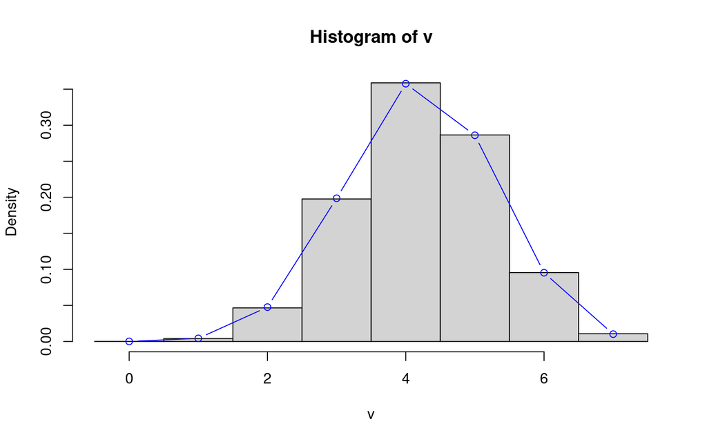

```r
# Número de perros
M = 7
# Número de otros animales
N = 13
# Número de animales extraídos del grupo
k = 12
n = 6
# Probabilidad de obtener 6 perros en 12 extracciones
dhyper(n, M, N, k)
[1] 0.09535604
# Primer cuartil
qhyper(0.25, M, N, k)
[1] 3
# Mediana
qhyper(0.5, M, N, k)
[1] 4
# Tercer cuartil
qhyper(0.75, M, N, k)
[1] 5
# Generación de valores aleatorios
rhyper(100000, M, N, k) -> v
x = min(v):max(v)
# Histograma
hist(v, breaks=seq(min(x)-0.5, max(x)+0.5, by=1), freq=FALSE)
lines(x, dhyper(x, M, N, k), type='b', col='blue')
```

###### 4.3.6.3.0.1 (volver al índice)

## 4.4 Continuas

Una v.a. $\ X : \Omega \longrightarrow \mathbb{R}\$ es continua cuando su función de distribución $\ F_X : \mathbb{R} \longrightarrow [0, 1]\$ es continua

En este caso, $\ F_X(x)=F_X(x^-)\$ y, por este motivo,

$$p(X=x)=0 \quad \forall\ x \in \mathbb{R}$$

pero esto no significa que sean sucesos imposibles

**Función de densidad:** es una función $\ f : \mathbb{R} \longrightarrow \mathbb{R}\$ que satisface:

- $f(x) \ge 0 \quad \forall \ x \in \mathbb{R}$
- $\int_{-\infty}^{+\infty}{f(t)\cdot dt}=1$

Una función de densidad puede tener puntos de discontinuidad

**Función de distribución:** toda variable aleatoria $X$ con función de distribución

$$F(x)=\int_{-\infty}^{x}{f(t)\cdot dt} \quad \forall\ x \in \mathbb{R}$$

para cualquier densidad $f$ es una v.a. continua, entonces se dirá que $f$ es la función de densidad de $X$

A partir de ahora, se considerarán solamente las v.a. $X$ continuas que tienen función de densidad

**Esperanza:** La esperanza de una v.a. continua $X$ con densidad $f_X$ es

$$E(X)=\int_{-\infty}^{+\infty}{x\cdot f_X(x)\cdot dx}$$

Si el dominio $D_X$ de $X$ es un intervalo de extremos $\ a<b$, entonces

$$E(X)=\int_{a}^{b}{x \cdot f_X(x) \cdot dx}$$

Sea $g:D_X\longrightarrow \mathbb{R}$ una función continua. Entonces,

$$E(g(X)) = \int_{-\infty}^{+\infty}g(x)\cdot f_X(x)\cdot dx$$

Si el dominio $D_X$ de $X$ es un intervalo de extremos $a<b$, entonces

$$E(g(X))=\int_a^b g(x)\cdot f_X(x)\cdot dx$$

**Varianza:** la varianza de una v.a. continua, como en el caso discreto

$$Var(X)=E((X-E(X))^2)$$

y se puede demostrar que

$$Var(X)=E(X^2)-(E(X))^2$$

### 4.4.1 Uniforme

Una v.a. continua $X$ tiene una distribución uniforme sobre el intervalo real $[a,b]$ con $a<b, X \sim \text{U}(a,b)$ si su función de densidad es

$$f_X(x)=
\left\{
\begin{array}{rl}
\displaystyle\frac{1}{b-a} \quad & \text{si } a \le x \le b \\
0 \quad & \text{en cualquier otro caso}
\end{array}
\right.$$

Modela el elegir un elemento del intervalo $[a,b]$ de manera equiprobable

- El **dominio** de $X$ es $D_X = [a,b]$
- La **función de distribución** está dada por

$$F_X(x) =
\left\{
\begin{array}{rl}
0 \quad & \text{si }\ x \le a \\
\displaystyle\frac{x-a}{b-a} \quad & \text{si }\ a < x < b \\
1 \quad & \text{si }\ x \ge b
\end{array}
\right.$$

- La **esperanza** es $E(X)=\displaystyle\frac{b+a}{2}$
- La **varianza** es $Var(X)=\displaystyle\frac{(b-a)^2}{12}$

#### 4.4.1.1 Funciones en `R`

```r
# min = a
# max = b
dunif(x, min=0, max=1)
punif(q, min=0, max=1)
qunif(p, min=0, max=1)
runif(n, min=0, max=1)
```

#### 4.4.1.2 Funciones en `python`

Si $X \sim U(a, b)$, entonces $\ \displaystyle{Z=\frac{x-a}{b-a} \sim U(0,1)}$

##### 4.4.1.2.1 Propiedad: Cambio lineal

Sea $X$ una v.a. $U(a,b)$

Si $\ scale \ne 0\$ y $\ loc\$ son dos constantes entonces:

- si $\ scale>0 \rightarrow T=scale \cdot X + loc\$ sigue una ley $U(scale \cdot a + loc, scale \cdot b + loc)$
- si $\ scale<0 \rightarrow T=scale \cdot X + loc\$ sigue una ley $U(scale \cdot b + loc, scale \cdot a + loc)$

```python
from scipy.stats import uniform
# A uniform continuous random variable.
# In the standard form, the distribution is uniform on ``[0, 1]``. Using the parameters ``loc`` and ``scale``, one obtains the uniform distribution on ``[loc, loc + scale]``.
# loc = a
# scale = b - a

uniform.pmf(x, loc=0, scale=1)
uniform.cdf(x, loc=0, scale=1)
uniform.ppf(q, loc=0, scale=1)
uniform.rvs(loc=0, scale=1, size=1)
```

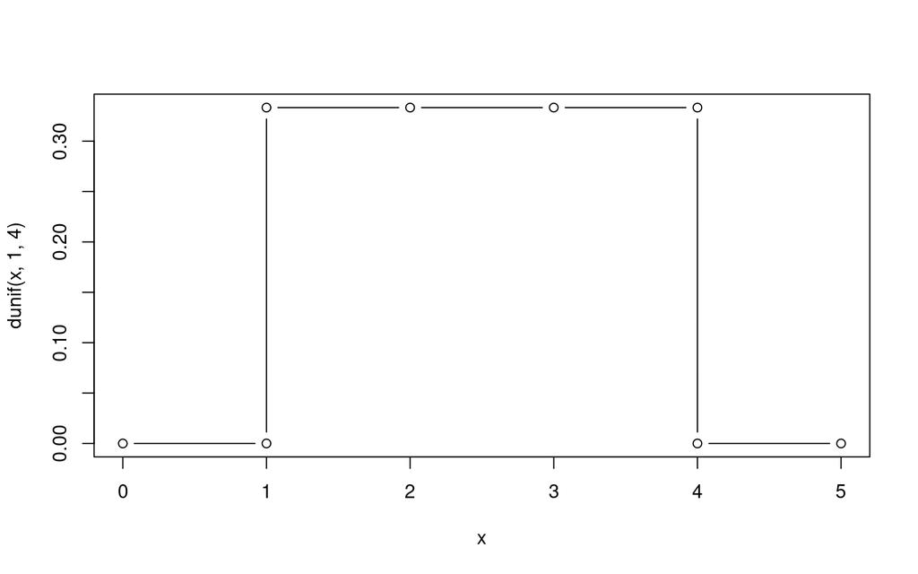

```r
a = 0
b = 1

x = c(0, 0.9999, 1, 2, 3, 4, 4.0001, 5)
plot(x, dunif(x, 1, 4), type='b')
```

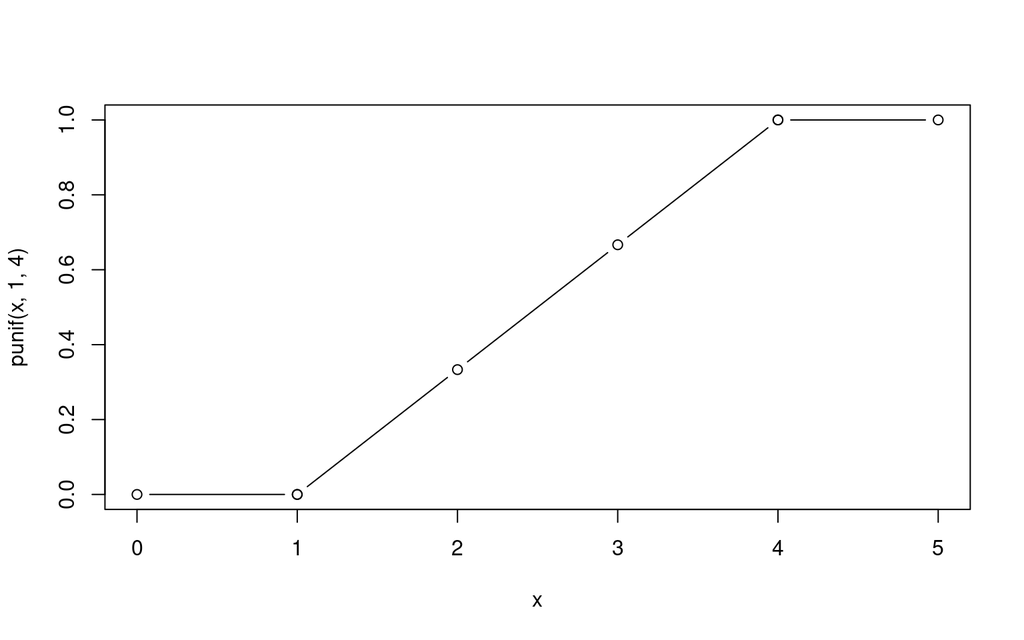

```r
plot(x, punif(x, 1, 4), type='b')
```

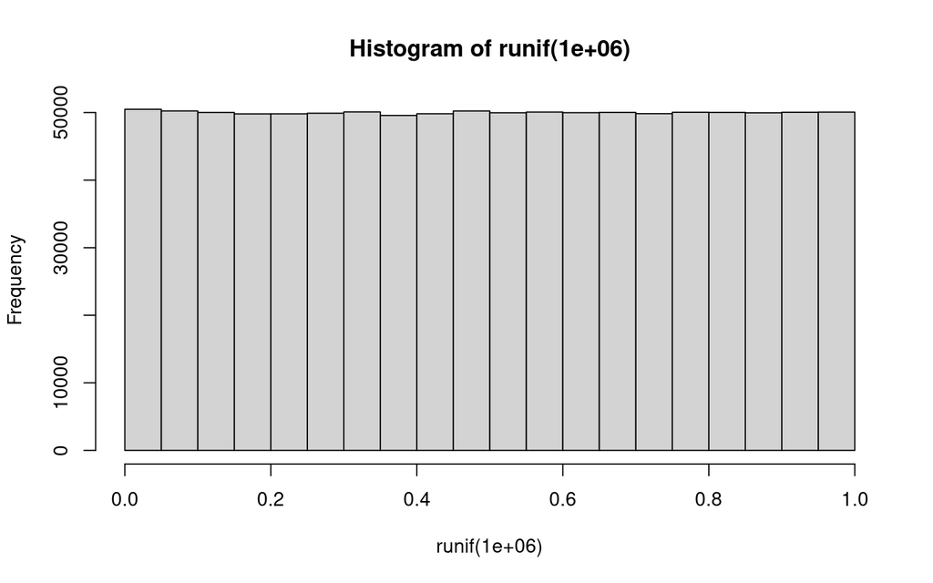

```r
hist(runif(1000000))
```

###### 4.4.1.2.1.1 (volver al índice)

### 4.4.2 Exponencial

Una variable aleatoria $X$ tiene distribución exponencial de parámetro $\lambda$, $X \sim \text{Exp}(\lambda)$, si su función de densidad es

$$f_X(x)=
\left\{
\begin{array}{rl}
0 \quad & \text{si } x \le 0 \\
\lambda \cdot e^{-\lambda x} \quad & \text{si } x > 0
\end{array}
\right.$$

**Teorema**: Si se tiene un proceso de $\text{Poisson}$ con parámetro $\lambda$ por unidad de tiempo, el tiempo que pasa entre dos sucesos consecutivos es una variable aleatoria $\text{Exp}(\lambda)$

**Propiedad de la pérdida de memoria**: Si $X$ es una v.a. $\text{Exp}(\lambda)$, entonces

$$P(X>s+t|X>s)=P(X>t)\quad \forall\ s,t>0$$

- El **dominio** de $X$ será $D_X=[0,\infty)$
- La **función de distribución** está dada por

$$F_X(x)=
\left\{
\begin{array}{rl}
0 & \text{si } x \le 0 \\
1-e^{-\lambda x} & \text{si } x > 0
\end{array}
\right.$$

- La **Esperanza** es $E(X)=\displaystyle\frac{1}{\lambda}$
- La **Varianza** es $Var(X)=\displaystyle\frac{1}{\lambda^2}$
- El **Momento de orden $n$** es $E(X^n)=\displaystyle\frac{n!}{\lambda^n}$
- El **coeficiente de asimetría** es 2
- La **curtosis** es 9

#### 4.4.2.1 Funciones en `R`

```r
# rate = lambda
dexp(x, rate=1)
pexp(q, rate=1)
qexp(p, rate=1)
rexp(n, rate=1)
```

#### 4.4.2.2 Funciones en `python`

```python
from scipy.stats import expon
# loc
# scale = E(X)

expon.pmf(x, loc=0, scale=1)
expon.cdf(x, loc=0, scale=1)
expon.ppf(q, loc=0, scale=1)
expon.rvs(loc=0, scale=1, size=1)
```

#### 4.4.2.3 Ejercicio

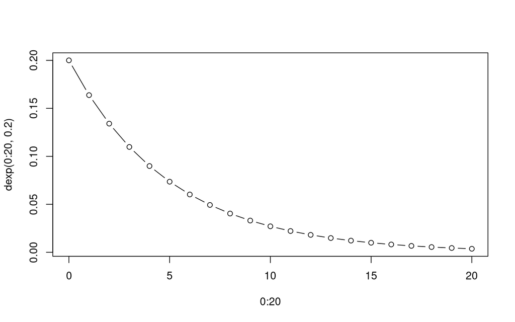

```r
plot(0:20, dexp(0:20, 0.2), type='b')
```

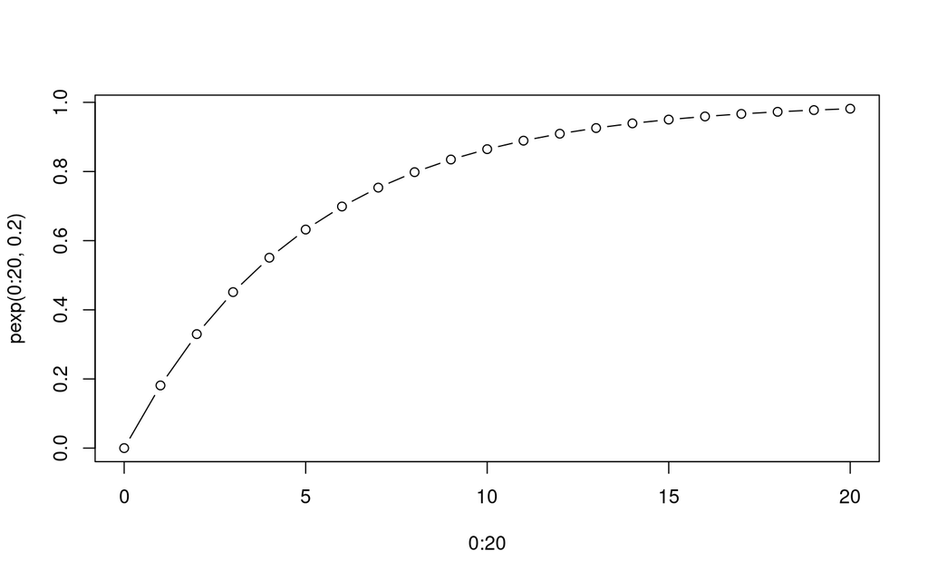

```r
plot(0:20, pexp(0:20, 0.2), type='b')
```

###### 4.4.2.3.0.1 (volver al índice)

### 4.4.3 Normal

Una v.a. $X$ tiene distribución normal o gaussiana de parámetros $\mu$ y $\sigma$, $X \sim \mathcal{N}(\mu, \sigma)$ si su función de densidad es

$$f_X(x)=\frac{1}{\sigma\sqrt{2\pi}}{e^{-\frac{1}{2}\cdot\left(\frac{x-\mu}{\sigma}\right)^2}} \quad \forall\ z \in \mathbb{R}$$

La gráfica de $f_X$ es conocida como la **Campana de Gauss**

Cuando $\mu = 0$ y $\sigma = 1$, se dice que la v.a. $X$ es **estándar** y se indicará usualmente como $Z$, la cuál tendrá **función de densidad**

$$f_Z(z) = \frac{1}{\sqrt{2\pi}}e^{-\frac{z^2}{2}} \quad \forall\ z \in \mathbb{R}$$

- La **Esperanza** es $E(X)=\mu$
- La **Varianza** es $Var(X)=\sigma^2$
- El **coeficiente de asimetría** es 0
- La **curtosis** es 3

En particular, si $Z$ sigue una distribución estándar

- La **Esperanza** es $E(X)=0$
- La **Varianza** es $Var(X)=1$

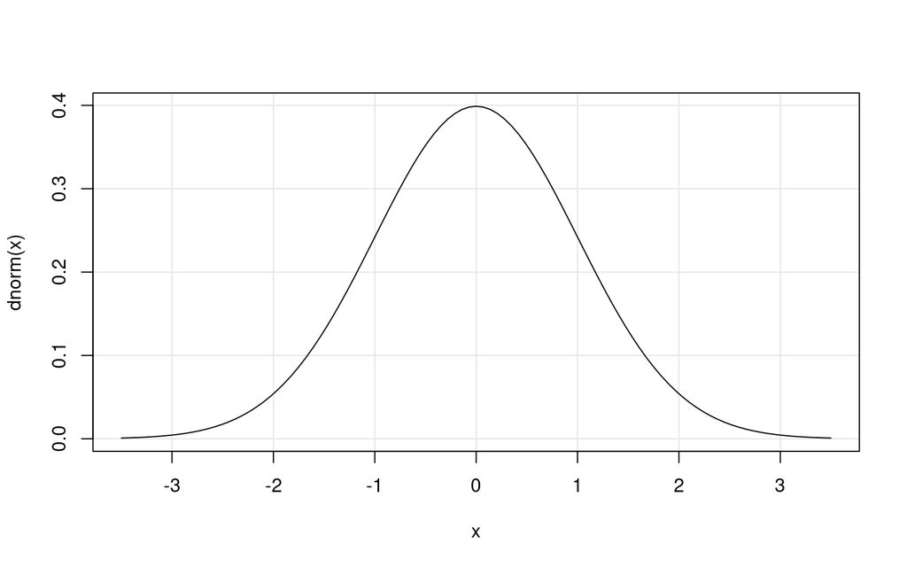

```r
curve(
  dnorm(x),
  from=-3.5, to=3.5,
  panel.first=
    abline(
      h=seq(from=0, to=0.4, by=0.1),
      v=seq(from=-4, to=4, by=1),
      col="gray90"))
```

- **Estandarización de una v.a. normal**: Si $X$ es una v.a. $\mathcal{N}(\mu,\sigma)$, entonces

$$Z=\frac{X-\mu}{\sigma} \sim \mathcal{N}(0,1) \quad y \quad X=\sigma\cdot Z + \mu \sim \mathcal{N}(\mu,\sigma)$$

Las probabilidades de una normal estándar $Z$ determinan las de cualquier $X$ de tipo $\mathcal{N}(\mu, \sigma)$

$$p(X\le x)=p\left( \frac{X-\mu}{\sigma} \le \frac{x-\mu}{\sigma} \right) = p\left( Z\le\frac{x-\mu}{\sigma} \right)$$

Los puntos de inflexión están en $\ \mu-\sigma\$ y $\ \mu+\sigma$.

- **Transformación lineal de la distribución normal**: Sea $\ X\$ una variable $\ \mathcal{N}(\mu,\sigma)\$ entonces la variable $\ Y=aX+b\$ con $\ a \ne 0,\ b \in \mathbb{R}\$ tiene distribución $\ \mathcal{N}(a\mu+b,\ |a|\sigma)$

#### 4.4.3.1 Funciones en `R`

```r
# library stats
dnorm(x, mean=0, sd=1)
pnorm(q, mean=0, sd=1)
qnorm(p, mean=0, sd=1)
rnorm(n, mean=0, sd=1)
```

#### 4.4.3.2 Funciones en `python`

```python
from scipy.stats import norm
# loc = mean
# scale = standard deviation.

norm.pmf(x, loc=0, scale=1)
norm.cdf(x, loc=0, scale=1)
norm.ppf(q, loc=0, scale=1)
norm.rvs(loc=0, scale=1, size=1)
```

#### 4.4.3.3 Cuantiles

Si $\ X\$ es una v.a. con dominio $\ D_X\$ y $\ 0<q<1\$ llamaremos cuantil de orden $\ q\$ al menor valor perteneciente al dominio $\ X_q\in D_X\$ tal que

$$P(X \le x_q) \ge q$$

En `R`, cada distribución $\ X\$ tiene una función `qX(p, ...)` que devuelve precisamente el cuantil $\ x_p\$ tal que $\ P(X \le x_p) \ge p$

- El **coeficiente de asimetría de Pearson** es

$$\gamma_1=
E\left(\left(\frac{X-\mu}{\sigma}\right)^{3}\right)=
\frac{\mu_{3}}{\sigma^{3}}$$

- La **curtosis de Pearson** es

$$\gamma_2=
E\left(\left(\frac{X-\mu}{\sigma}\right)^{4}\right)=
\frac{\mu_{4}}{\sigma^{4}}$$

- La **función generatriz de momentos** de una v.a. $X$ es

$$m_X(t)=
E\left(e^{tX}\right)$$

- El **momento de orden $n$** de una v.a. también se puede calcular como

$$m_n=
E\left(X^n\right)=
\left.\frac{d^n\left(m_X(t)\right)}{dt^n}\right|_{t=0}=
m_X^{(n)}(0)$$

- La **función generatriz acumulativa** de una v.a. $X$ es

$$K_X(t)=
\text{ln}\left(m_X(t)\right)$$

$$\left.\frac{d(K_X(t))}{dt}\right|_{t=0}=
\mu_X=
E(X)$$

$$\left.\frac{d^2(K_X(t))}{dt^2}\right|_{t=0}=
\sigma_X^2=
Var(X)$$

- La **función de probabilidad** $f_X(k)$ se puede calcular a partir de la *función generatriz de momentos* como

$$f_X(k)=
\frac{m_X^{(k)}(0)}{k!}$$

- La **función característica** de una v.a. $X$ es

$$\phi_X(w)=
E\left(e^{\text{i}wX}\right) \qquad \text{donde }\ \ \text{i}=\sqrt{-1}$$

- La relación entra la **función característica** y los **momentos de roden $n$** de una v.a. $X$ es la siguiente

$$m_n=
E(X^n)=
\frac{1}{\text{i}^n}\cdot\left.\frac{d^n(\phi_X(w))}{dw^n}\right|_{w=0}=
\frac{1}{\text{i}^n}\cdot\phi_X^{(n)}(0)$$

#### 4.4.3.4 Binomio de Newton

$$\begin{array}{lllll}
\displaystyle(x+y)^n&=&
\displaystyle\sum_{k=0}^{n}{{n \choose k}\cdot x^{n-k}\cdot y^{k}}&=&
\displaystyle\sum_{k=0}^{n}{\frac{n!}{k!\cdot(n-k)!}\cdot x^{n-k}\cdot y^k} \\[5pt]
\displaystyle(x-y)^n&=&
\displaystyle\sum_{k=0}^{n}{(-1)^k\cdot{n \choose k}\cdot x^{n-k}\cdot y^{k}}&=&
\displaystyle\sum_{k=0}^{n}{(-1)^k\cdot\frac{n!}{k!\cdot(n-k)!}\cdot x^{n-k}\cdot y^k}
\end{array}$$

#### 4.4.3.5 Función exponencial

La **función exponencial** ${\displaystyle e^{x}}$ tiene como serie de Maclaurin

$$e^{x}=
\sum _{n=0}^{\infty}{\frac{x^{n}}{n!}}=
1+x+{\frac{x^{2}}{2!}}+{\frac {x^{3}}{3!}}+\cdots$$

y converge para toda ${\displaystyle x}$.

###### 4.4.3.5.0.1 Referencia

- https://es.wikipedia.org/wiki/Serie_de_Taylor#Funci%C3%B3n_exponencial

$$$$

## 4.5 Conjuntas

### 4.5.1 Función de distribución

Dada una **v.a. bidimensional** $(X,\ Y)$, se define su **función de distribución** $F_{XY}$ a la función definida sobre $\mathbb{R}^2$ de la manera siguiente:

$$\begin{array}{rl}
F_{XY}:\mathbb{R}^2 & \longrightarrow \mathbb{R} \\
(x,\ y) & \longrightarrow F_{XY}(x,\ y)=P(X\leq x,\ Y\leq y)
\end{array}$$

Las v.a. $X$ y $Y$ se llaman **variables aleatorias marginales** y sus funciones de distribución $F_X$ y $F_Y$ pueden hallarse a partir de la distribución conjunta de la siguiente forma:

$$F_X(x)=F_{XY}(x,\ \infty), \quad F_Y(y)=F_{XY}(\infty,\ y)$$

para todo $x,\ y \in \mathbb{R}$.

Dados $\ x_1<x_2\$ y $\ y_1<y_2\$, consideramos $B$ el rectángulo de vértices $(x_1,y_1)$, $(x_1,y_2)$, $(x_2,y_1)$ y $(x_2,y_2): (x_1,x_2]\times(y_1,y_2]$. Entonces,

$$P((X,\ Y)\in B)=
F_{XY}(x_2,\ y_2)-F_{XY}(x_2,\ y_1)-F_{XY}(x_1,\ y_2)+F_{XY}(x_1,\ y_1)$$

$$$$

### 4.5.2 Variable discreta

Dada una **v.a. bidimensional discreta** $(X,\ Y)$, se define su **función de probabilidad** $P_{XY}$ para un valor $(x,\ y)\in\mathbb{R}^2$ de la siguiente forma:

$$\begin{array}{rl}
P_{XY}:\mathbb{R}^2 & \longrightarrow \mathbb{R} \\
(x,\ y) & \longrightarrow P_{XY}(x,\ y)=P(X=x,\ Y=y)
\end{array}$$

La suma de todos los valores de la **función de probabilidad conjunta** cobre el conjunto de valores siempre vale 1:

$$\sum_{i}\sum_{j}P_{XY}(x_i,\ y_j)=1$$

La relación entre la **función de distribución conjunta** y la **función de probabilidad conjunta** es:

$$F_{XY}(x,\ y)=
\sum_{x_i\leq x,\ y_j\leq y}{P_{XY}(x_i,\ y_j)}$$

#### 4.5.2.1 Función de probabilidad marginal

Las **funciones de probabilidad marginales** $P_X(x_i)$ y $P_Y(y_j)$ se calculan usando las siguientes expresiones:

$$P_{X}(x)=\sum_{j}{P_{XY}(X=x,\ Y=y_j)}$$
$$P_{Y}(y)=\sum_{i}{P_{XY}(X=x_i,\ Y=y)}$$

$$$$

### 4.5.3 Variable continua

La relación que hay entre la **función de distribución** $F_{XY}$ y la **función de densidad** $f_{XY}$ es la siguiente:

$$F_{XY}(x,\ y)=\int_{-\infty}^{x}{\int_{-\infty}^{y}{f_{XY}(u,\ v)\ du\ dv}}$$

La relación que hay entre la **función de densidad** $f_{XY}$ y la **función de distribución** $F_{XY}$ es:

$$f_{XY}(x,\ y)=\frac{\partial^2F_{XY}(x,\ y)}{\partial x\partial y}$$

Las **funciones de densidad marginales** de las variables $X$ y $Y$, $f_X(x)$ y $f_Y(y)$ respectivamente, se calculan de la siguiente manera:

$$f_X(x)=
\int_{-\infty}^{\infty}{f_{XY}(x,\ y)\ dy}, \quad
f_Y(y)=
\int_{-\infty}^{\infty}{f_{XY}(x,\ y)\ dx}$$

$$$$

### 4.5.4 Distribución Gaussiana bidimensional

La distribución de la v.a. bidimensional $(X,\ Y)$ es **gaussiana bidimensional** dependiendo del parámetro $\rho$ (rho) si su **función de densidad conjunta** es:

$$f_{XY}(x,\ y)=\frac{1}{2\pi\sqrt{1-\rho^2}}e^{-\frac{\left(x^2-2\rho xy+y^2\right)}{2\left(1-\rho^2\right)}}, \quad -\infty<x,\ y<\infty, \quad |\rho|<1$$

Para cualquier punto $(x,\ y)\in\mathbb{R}^2$, la función de densidad es no nula: $f_{XY}(x,\ y)>0$.

La **función de densidad** tiene un único máximo absoluto en el punto $(0,\ 0)$. Para $\rho=0$, dicho máximo alcanza el mínimo valor posible y si $\rho\to\pm1$, dicho máximo tiende a $\infty$.

Las **densidades marginales** $f_X(x)$ y $f_Y(y)$ son normales $N(0,\ 1)$.

$$$$

### 4.5.5 Independencia de v.a. conjuntas

Las **v.a. discretas** $X$ y $Y$ son independientes si:

$$P_{XY}(x_i,\ y_j)=P_X(x_i)\cdot P_Y(y_j), \quad i=1,2,\dots,\quad j=1,2,\dots$$

Las **v.a. continuas** $X$ y $Y$ son independientes si:

$$f_{XY}(x,\ y)=f_X(x)\cdot f_Y(y), \quad \text{para todo } x,\ y \in \mathbb{R}$$
También, las v.a. continuas $X$ y $Y$ son independientes si:

$$F_{XY}(x,\ y)=F_X(x)\cdot F_Y(y), \quad (x,\ y)\in\mathbb{R}^2$$

Las **v.a. continuas** $X$ y $Y$ de la **distribución gaussiana bidimensional** son independientes cuando $\rho=0$.

$$$$

### 4.5.6 Valor esperado

El **valor esperado** de $g(X,\ Y)$ se puede hallar usando la siguiente expresión:

$$E(g(X,\ Y))=
\left\{
\begin{array}{ll}
\displaystyle\sum_{x_i}\sum_{y_j}{g(x_i,\ y_j)\cdot P(x_i,\ y_j)} &
\qquad\text{para v.a. discreta} \\[10pt]
\displaystyle\int_{-\infty}^{\infty}{\int_{-\infty}^{\infty}{g(x,\ y)\cdot f_{XY}(x,\ y)\ dx\ dy}} &
\qquad\text{para v.a. continua}
\end{array}
\right.$$

Si las v.a. $X$ y $Y$ son independientes, y $g(x,\ y)$ se puede expresar como $g_x(x)\cdot g_y(y)$ para todo valor $x,\ y \in \mathbb{R}$. En este caso, el valor esperado de $g(x,\ y)$ se puede calcular como:

$$E(g(X,\ Y))=
E_X(g_x(X))\cdot E_Y(g_y(Y))$$

Es decir

$$E(g(X,\ Y))=
\left\{
\begin{array}{ll}
\displaystyle\left(\sum_{x_i}{g_x(x_i)\cdot P_X(x_i)}\right)\cdot\left(\sum_{y_j}{g_y(y_j)\cdot P_Y(y_j)}\right) &
\qquad\text{para v.a. discreta} \\[10pt]
\displaystyle\left(\int_{-\infty}^{\infty}{g_x(x)\cdot f_X(x)\ dx}\right)\cdot\left(\int_{-\infty}^{\infty}{g_y(y)\cdot f_Y(y)\ dy}\right) &
\qquad\text{para v.a. continua}
\end{array}
\right.$$

$$$$

### 4.5.7 Momentos conjuntos

El **momento conjunto de orden $(k,\ l)$** para la v.a. bidimensional $(X,\ Y)$ se define como:

$$E\left(X^kY^l\right)=
\left\{
\begin{array}{ll}
\displaystyle\sum_{x_i}{\sum_{y_j}{x_i^k\ y_j^l\ P_{XY}(x_i,\ y_j)}} &
\qquad\text{para v.a. discreta} \\[10pt]
\displaystyle\int_{-\infty}^{\infty}{\int_{-\infty}^{\infty}{x^k\ y^l\ f_{XY}(x,\ y)\ dx\ dy}} &
\qquad\text{para v.a. continua}
\end{array}
\right.$$

Donde $\ \ k,\ l\in\mathbb{N}$.

#### 4.5.7.1 Observaciones

Si $l=0$, los momentos conjuntos de orden $(k,\ 0)$ coinciden con los momentos de orden $k$ de la v.a. $X$.

Si $k=0$, los momentos conjuntos de orden $(0,\ l)$ coinciden con los momentos de orden $l$ de la v.a. $Y$.

Para $k=1$ y $l=1$ se tiene el momento conjunto de orden $(1,\ 1)$: $E(X\cdot Y)$, denominado **correlación entre las varaibles $X$ y $Y$**. Si $E(X\cdot Y)=0$, se dice que las v.a. $X$ y $Y$ con **ortogonales**.

$$$$

### 4.5.8 Momentos conjuntos centrados en las medias

El **momento conjunto de orden $(k,\ l)$ centrado en las medias** para la v.a. bidimensional $(X,\ Y)$ se define como:

$$E\left(\left(X-\mu_X\right)^k\ \left(Y-\mu_Y\right)^l\right)=
\left\{
\begin{array}{ll}
\displaystyle\sum_{x_i}{\sum_{y_j}{(x_i-\mu_X)^k\ (y_j-\mu_Y)^l\ P_{XY}(x_i,\ y_j)}} &
\qquad\text{para v.a. discreta} \\[10pt]
\displaystyle\int_{-\infty}^{\infty}{\int_{-\infty}^{\infty}{(x-\mu_X)^k\ (y-\mu_Y)^l\ f_{XY}(x,\ y)\ dx\ dy}} &
\qquad\text{para v.a. continua}
\end{array}
\right.$$

Donde $\ \ k,\ l\in\mathbb{N}$, $\ \ \mu_X=E(X)\ \$ y $\ \ \mu_Y=E(Y)$.

$$$$

### 4.5.9 Covarianza entra las variables

El **momento conjunto centrado en las medias** para $k=1$ y $l=1$ se denomina **covarianza** entre las variables $X$ y $Y$:

$$\text{Cov}(X,\ Y)=E((X-\mu_X)\cdot(Y-\mu_Y))$$

La covarianza puede calcularse a partir de la **correlación** entre las variables:

$$\text{Cov}(X,\ Y)=E(X\cdot Y)-\mu_X\cdot\mu_Y$$

Las v.a. $X$ y $Y$ son independientes si $\text{Cov}(X,\ Y)=0$, es decir, $E(X\cdot Y)=\mu_X\cdot\mu_Y$

$$$$

### 4.5.10 Varianza

La **varianza** de la suma o resta de las v.a. $X$ y $Y$, se puede calcular utilizando la siguiente expresión:

$$\text{Var}(X\pm Y)=
E\left(\left(X\pm Y\right)^2\right)-(E(X\pm Y))^2=
\text{Var}(X)+\text{Var}(Y)\pm2\text{Cov}(X,\ Y)$$

$$$$

### 4.5.11 Coeficiente de correlación

El **coeficiente de correlación** entre las v.a. $X$ y $Y$ se define como:

$$\rho_{XY}=
\frac{\text{Cov}(X,\ Y)}{\sqrt{\text{Var}(X)}\cdot\sqrt{\text{Var}(Y)}}=
\frac{E(X\cdot Y)-\mu_X\cdot\mu_Y}{\sqrt{E(X^2)-\mu_X^2}\cdot\sqrt{E(Y^2)-\mu_Y^2}}$$

Si las v.a. $X$ y $Y$ con independientes entonces $\rho_{XY}=0$

El **coeficiente de correlación** es un valor normalizado ya que siempre está entre -1 y 1, es decir que $\ -1\leq\rho_{XY}\leq1$.

$$$$

### 4.5.12 Variable aleatoria condicional discreta

Sean $(X,\ Y)$ una v.a. bidimensional discreta, la probabilidad de que $Y=y_j|X=x_1$ se define como:

$$P_{Y|X=x_i}(y_j)=
P(Y=y_j|X=x_i)=
\frac{P(X=x_i,\ Y=y_j)}{P(X=x_i)}=
\frac{P_{XY}(x_i,\ y_j)}{P_{X}(x_i)}$$

Al ser $\ Y|X=x_i\$ una v.a. unidimensional, se debe verificar que:

$$\sum_{y_j}{P_{Y|X=x_i}(y_j)}=1$$

Si las v.a. $X$ y $Y$ son independientes, se tiene que:

$$P_{Y|X=x_i}(y_j)=P_Y(y_i)$$

$$$$

### 4.5.13 Variable aleatoria condicional continua

Sean $(X,\ Y)$ una v.a. bidimensional continua, la probabilidad de que $Y=y|X=x$ se define como:

$$f_{Y|X=x}(y)=
\frac{f_{XY}(x,\ y)}{f_{X}(x)}$$

Al ser $\ Y|X=x_i\$ una v.a. unidimensional, se debe verificar que:

$$\int_{-\infty}^{\infty}{f_{Y|X=x}(y)\ dy}=1$$

Si las v.a. $X$ y $Y$ son independientes, se tiene que:

$$f_{Y|X=x}(y)=f_Y(y)$$

$$$$

### 4.5.14 Valor esperado condicional

Sean $(X,\ Y)$ una v.a. bidimensional, se define el **valor esperado de la variable $Y$ dado que $X=x$** como $E(Y|x)$, es decir, el valor esperado de la **v.a. condicional $Y|X=x$**:

$$E(Y|x)=
\left\{
\begin{array}{ll}
\displaystyle\sum_{y_j}{y_j\ P_{Y|X=x}(y_j)} & \qquad \text{para v.a. discreta} \\[10pt]
\displaystyle\int_{-\infty}^{\infty}{y\ f_{Y|X=x}(y)\ dy} & \qquad \text{para v.a. continua}
\end{array}
\right.$$

### 4.5.15 Distribución gaussiana $n$-dimensional (normal de $n$ dimensiones)

La distribución de la v.a. $n$-dimensional $(X_1,\dots,X_n)$ es **gaussiana $n$-dimensional** dependiendo del **vector de medias $\mathbf{\mu}$** y de la **matriz de covarianzas $\mathbf{\Sigma}$** si su **función de densidad conjunta** es:

$$f_{X_1\dots X_n}(x_1,\dots,x_n)=
\frac{1}{(2\pi)^{\frac{n}{2}}\sqrt{\mathbf{|\Sigma|}}}
\mathrm{e}^{-\frac{1}{2}(\mathbf{x-\mu})^{\top}\mathbf{\Sigma}^{-1}(\mathbf{x-\mu})}, \qquad -\infty<x_1,\dots,x_n<\infty$$

Se denota $\mathbf{X}=(X_1,\dots,X_n)$ con $\mathbf{X}=\mathcal{N}(\mathbf{\mu,\Sigma})$

donde $\mathbf{x}=\begin{pmatrix}x_1\\\vdots\\ x_n\end{pmatrix}$, $\mathbf{\mu}=\begin{pmatrix}\mu_1\\\vdots\\ \mu_n\end{pmatrix}$

### 4.5.16 Transformación lineal de una distribución normal multivariante

Sea $\mathbf{X}=\mathcal{N}(\mathbf{\mu, \Sigma})$ una distribución **normal $n$-dimensional**. Sea la variable $k$-dimensional $\mathbf{Y}$ construida como $\mathbf{Y}=\mathbf{c}+\mathbf{CX}$, con $\mathbf{C}$ una matriz $k\times n$ y $\mathbf{c}$ un vector $k$-dimensional. Entonces la variable $\mathbf{Y}$ se distribuye como una variable **normal $k$-dimensional** de media $\mathbf{\mu_Y}=\mathbf{c}+\mathbf{C\mu}$ y matriz de covarianzas $\mathbf{\Sigma_Y}=\mathbf{C\Sigma C^\top}$

$$\mathbf{Y}=
\mathcal{N}(\mathbf{c}+\mathbf{C\mu},\ \mathbf{C\Sigma C^\top})$$

### 4.5.17 Suma de dos normales independientes

Sean $X$ y $Y$ v.a. independientes donde $\ X\sim\mathcal{N}(\mu_1,\ \sigma_1)\$ y $\ Y\sim\mathcal{N}(\mu_2,\ \sigma_2)$, entonces

$$X+Y\sim\mathcal{N}\left(\mu_1+\mu_2,\ \sqrt{\sigma_1^2+\sigma_2^2}\right)$$

### 4.5.18 Teorema central del límite

El **Teorema Central del Límite** se aplica a la práctica en la forma siguiente:

Sea $\{X\}_{n=1}^{\infty}$ una sucesión de variables aleatorias independientes e idénticamente distribuidas con $E(X_i)=\mu$ y $Var(X_i)=\sigma^2$. Entonces, podemos aproximar para $n$ grande $(n\geq30)$, la media muestral $\overline{X}_n$ por:

$$\overline{X}_n=\frac{1}{n}\cdot\sum_{i=1}^{n}{X_i}\approx
\mathcal{N}\left(\mu,\ \frac{\sigma}{\sqrt{n}}\right)$$

o también:

$$X_n=\sum_{i=1}^{n}{X_i}\approx
\mathcal{N}\left(n\mu,\ \sigma\sqrt{n}\right)$$

Las aproximaciones anteriores se pueden obtener teniendo en cuenta que el Teorema Central del Límite nos dice que la

$$Z_n=
\frac{\displaystyle\sum_{i=1}^{n}{X_i}-n\mu}{\sigma\sqrt{n}}\approx
\mathcal{N}(0,\ 1) \Rightarrow
\sum_{i=1}^{n}{X_i}\approx
\sigma\sqrt{n}\cdot\mathcal{N}(0,\ 1)+n\mu=
\mathcal{N}\left(n\mu,\ \sigma\sqrt{n}\right)$$

Dividiendo por $n$ la aproximación anterior, obtenemos:

$$\overline{X}_n=
\frac{1}{n}\sum_{i=1}^{n}{X_i}\approx
\frac{1}{n}\cdot\mathcal{N}\left(n\mu,\ \sigma\sqrt{n}\right)=
\mathcal{N}\left(\mu,\ \frac{\sigma}{\sqrt{n}}\right)$$